# Project 2: Collegiate CSV file

For analysis, we are using a database of US college financial aid information made available through the US Department of Education College Affordability and Transparency Center. We hope to visualize some trends present in current college financial aid distributions throughout the nation. “Null” data points represent statstics that were unreported by their respective universities.

### Reproducing Our Work:

1. Create a GitHub repository for the project.
2. Create the folders for your project.
3. Find a csv file for statistical comparisons. Our CSV file was obtained by selecting the appropriate options from the website: http://collegecost.ed.gov/catc/Default.aspx
4. Clean up variable names using “college data wranging.r” file and use output to create SQL table in SQL Developer.
5. Import CSV into SQL Developer
6. Build an html file to document these steps.

Before generating plots, we run the ‘require.r’ file to make sure the necessary packages are in place.

```r
source("../require.R")
```

```
##
##
##
##
##
##
## Registering fonts with R
```

### Summary and Subset:

```r
source("../01 Data/summary.R", echo = TRUE)
```

```
##
## > df <- data.frame(fromJSON(getURL(URLencode("129.152.144.84:5001/rest/native/?query=\"select * from COLLEGESTATS where tuitionfees1314 is not null\"" .... [TRUNCATED]
##
## > head(df, 10)
##                                        NAME          PUBLICPRIVATE
## 1  Rocky Mountain College of Art and Design     Private for-profit
## 2          Colorado State University-Pueblo                 Public
## 3         Western State Colorado University                 Public
## 4   Yeshiva Toras Chaim Talmudical Seminary Private not-for-profit
## 5                   Albertus Magnus College Private not-for-profit
## 6                  University of Bridgeport Private not-for-profit
## 7      Central Connecticut State University                 Public
## 8                       Connecticut College Private not-for-profit
## 9                 University of Connecticut                 Public
## 10     Eastern Connecticut State University                 Public
```

[output cut: 162 more lines]

### Our Extract, Transform, Load file:

Based off of Professor Cannata’s R_ETL.R file we loaded our csv file into our Oracle account.

```r
source("../02 Data Wrangling/R_ETL.college.R", echo = TRUE)
```

```
##
## > setwd("/Users/Garner/Documents/DataVisualization/DV_RProject2/01 Data")
##
## > file_path <- "collegestats.csv"
##
## > df <- read.csv(file_path, stringsAsFactors = FALSE)
##
## > measures <- c("graduationRate", "tuitionFees1314",
## +     "enrollmentTotal", "studentFacultyRatio", "PFirstTimeUGAnyAid",
## +     "PFirstTimeUGAnyGra ..." ... [TRUNCATED]
##
## > for (n in names(df)) {
## +     df[n] <- data.frame(lapply(df[n], gsub, pattern = "[^ -~]",
## +         replacement = ""))
## + }
##
## > dimensions <- setdiff(names(df), measures)
##
## > if (length(measures) > 1 || !is.na(dimensions)) {
## +     for (d in dimensions) {
## +         df[d] <- data.frame(lapply(df[d], gsub, pattern = "[\"']", ..." ... [TRUNCATED]
##
## > write.csv(df, paste(gsub(".csv", "", file_path), ".reformatted.csv",
## +     sep = ""), row.names = FALSE, na = "")
##
## > tableName <- gsub(" +", "_", gsub("[^A-z, 0-9, ]",
## +     "", gsub(".csv", "", file_path)))
##
## > sql <- paste("CREATE TABLE", tableName, "(\n-- Change table_name to the table name you want.\n")
##
## > if (length(measures) > 1 || !is.na(dimensions)) {
## +     for (d in dimensions) {
## +         sql <- paste(sql, paste(d, "varchar2(4000),\n"))
## +     }
## + .... [TRUNCATED]
##
## > if (length(measures) > 1 || !is.na(measures)) {
## +     for (m in measures) {
## +         if (m != tail(measures, n = 1))
## +             sql <- paste(sq .... [TRUNCATED]
```

[output cut: 17 more lines]

```
##  PFirstTimeUGPell number(38,4),
##  avgAmtFirstTimeUGPell number(38,4),
##  PFirstTimeUGOtherFed number(38,4),
##  avgAmtFirstTimeUGOthFed number(38,4),
##  PFirstTimeUGStateGrant number(38,4),
##  avgAmtFirstTimeUGStateGrant number(38,4),
##  PFirstTimeUGInstituteGrant number(38,4),
##  avgAmtFirstTimeUGInsGrant number(38,4),
##  PFirstTimeUGLoanAid number(38,4),
##  avgAmtFirstTimeUGLoanAid number(38,4),
##  PFirstTimeUGFederalLoan number(38,4),
##  avgAmtFirstTimeUGFedLoan number(38,4),
##  PFirstTimeUGOtherLoan number(38,4),
##  avgAmtFirstTimeUGOthLoan number(38,4)
##  );
```

### Plot #1:

This plot uses some advanced piping techniques in R including the use of the cumulative distribution function. The visualization shows the average dollar amount of institutional grant money offered to college freshmen broken down by percentile vs. the school’s tuition and fees for the 2013-2014 academic school year.

Before analyzing this visualization, it is important to note that our data includes 1216 private not-for-profit schools, 560 public schools, and 303 private-for-profit schools.

Questions that arise from this visualization include: 1. Public universities seem to be offering institutional grants worth more than private not-for-profit universities, despite the fact that most all private not-for-profit schools have higher tuition and fees than their public counterparts. Are private not-for-profit universities overcharging for their services?

2. Private for-profit universities seem to appear most often in the top half of all universities, meaning they offer fairly weighty grants to their freshmen, but their tuition and fees are not as high as not-for-profit colleges. What’s going on here?

```
##
## > df <- data.frame(fromJSON(getURL(URLencode("129.152.144.84:5001/rest/native/?query=\"select * from COLLEGESTATS where tuitionfees1314 is not null\"" .... [TRUNCATED]
##
## > df %>% mutate(insgrant_percent = cume_dist(AVGAMTFIRSTTIMEUGINSGRANT)) %>%
## +     arrange(desc(insgrant_percent)) %>% ggplot(aes(x = insgrant_percen .... [TRUNCATED]
```

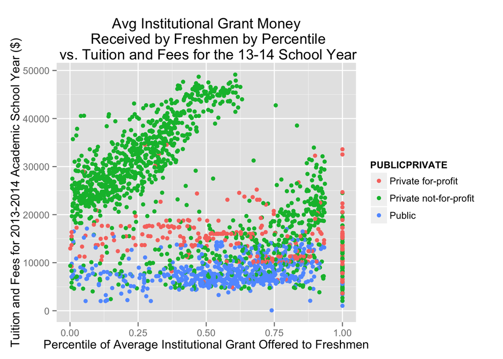

```
##
## > View(df)
```

```r
source("../02 Data Wrangling/plot1.R", echo = TRUE)
```

### Plot 2:

This plot uses some advanced piping techniques in R including the use of the cumulative distribution function. The visualization shows the average dollar amount of federal loan money offered to college freshmen grouped by the relative size of enrollment vs. the school’s tuition and fees for the 2013-2014 academic school year.

```
##
## > df <- data.frame(fromJSON(getURL(URLencode("129.152.144.84:5001/rest/native/?query=\"select * from COLLEGESTATS where tuitionfees1314 is not null\"" .... [TRUNCATED]
##
## > df <- df %>% mutate(Enroll_ment = cume_dist(ENROLLMENTTOTAL))
##
## > levels <- c(0, 0.33, 0.66, 1)
##
## > labels <- c("small", "medium", "large")
##
## > df <- df %>% filter(ENROLLMENTTOTAL != "null") %>%
## +     mutate(x = cut(Enroll_ment, levels, labels = labels))
##
## > df %>% group_by(x, PUBLICPRIVATE) %>% summarise(mean_institution_grants = mean(as.numeric(AVGAMTFIRSTTIMEUGFEDLOAN)),
## +     n = n(), mean_tuition = .... [TRUNCATED]
```

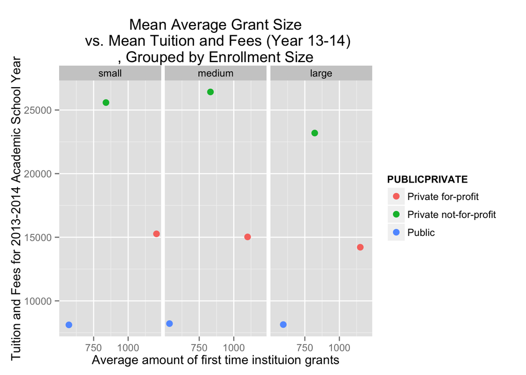

```
##
## > View(df)
```

```r
source("../02 Data Wrangling/plot2.R", echo = TRUE)
```

### Plot #3:

This plot uses some advanced piping techniques in R including the use of the cumulative distribution function. The visualization shows mean student faculty ratio of colleges vs mean tuition and fees for the 13-14 academic school year, grouped by quartile of average pell grant recipient amount and public/private for-profit/private not-for-profit schools.

R workflow employed in the generation of this visualization included the following steps: 1. Mutate data frame to create a new column, “pell_percent”, which contains the cumulative distribution value for each college’s average first time undergraduate student’s pell grant dollar amount. 2. Create vector called “levels” to designate quartiles for cumulative distribution values. 3. Create vector called “labels” which appropriate label quartiles. 4. Mutate data frame to create a new column which labels which quartile the college is in, dynamically applying the label using the cut function in tandem with the vectors mentioned in steps 2 and 3, put into column “x”. 5. Group data frame by “x” and “PUBLICPRIVATE” (school category), pipe data frame into the summarize function to obtain means of student faculty and tuition and fees for the grouping, and the finally pipe the data frame into the ggplot function.

This data is interesting because: 1. With a quick glance, you can see that schools with students that receive the highest pell grants on average have, on average, the lowest tuition rates. 2. In the case of both types of private schools, it is evident that schools with students who receive the highest pell grants on average, have, on average, the highest student faculty ratios. 3. In all three types of schools, schools with students who receive average pell grants that rank in the 3rd quartile have the highest tuition and fees.

Questions that arise from this visualization include: 1. Why do schools with students who receive pell grant amounts that rank in the highest quartile have the cheapest tuition and fees? Could schools be actively trying to appeal to economically disadvantaged students - those who receive pell grants - by having relatively low tuition and fees?

2. Do the same schools mentioned in number one make up for the fact that their tutition and fees are on average lower by highering less faculty, thus resulting in the higher student:faculty ratios seen in both types of private schools?

```
##
## > df <- data.frame(fromJSON(getURL(URLencode("129.152.144.84:5001/rest/native/?query=\"select * from COLLEGESTATS where tuitionfees1314 is not null\"" .... [TRUNCATED]
##
## > df <- df %>% mutate(pell_percent = cume_dist(AVGAMTFIRSTTIMEUGPELL))
##
## > levels <- c(0, 0.25, 0.5, 0.75, 1)
##
## > labels <- c("4th Q Highest Pell Grant", "3rd Q Highest Pell Grant",
## +     "2nd Q Highest Pell Grant", "1st Q Highest Pell Grant")
##
## > df <- df %>% filter(AVGAMTFIRSTTIMEUGPELL != "null") %>%
## +     mutate(x = cut(pell_percent, levels, labels = labels))
##
## > df %>% group_by(x, PUBLICPRIVATE) %>% summarise(mean_fac = mean(as.numeric(STUDENTFACULTYRATIO)),
## +     n = n(), mean_tuition = mean(as.numeric(TUI .... [TRUNCATED]
```

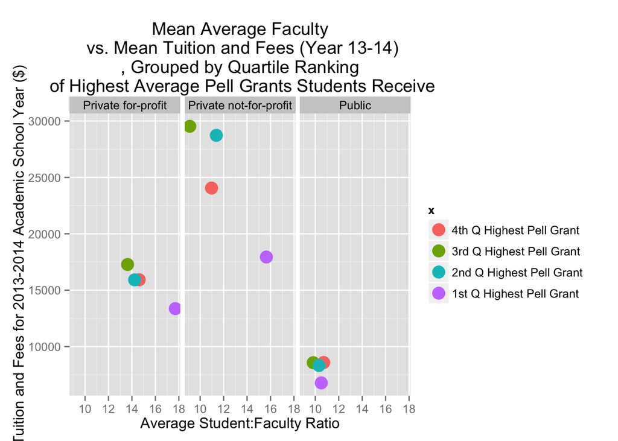

```r
source("../02 Data Wrangling/plot3.R", echo = TRUE)
```